# Programming II Final Project

## Alicia Guzman

### 12 December 2023

#### Q1

```python
import pandas as pd

s = pd.read_csv('social_media_usage.csv')

print("Dimensions of the DataFrame:", s.shape)
```

```
Dimensions of the DataFrame: (1502, 89)
```

#### Q2

```python
import numpy as np

def clean_sm(x):
    """Function to clean social media usage data"""
    return np.where(x == 1, 1, 0)

toy_df = pd.DataFrame({
    'Column_1': [1, 2, 3],
    'Column_2': [1, 1, 4]
})

cleaned_df = toy_df.applymap(clean_sm)
cleaned_df
```

|  | Column_1 | Column_2 |
| --- | --- | --- |
| 0 | 1 | 1 |
| 1 | 0 | 1 |
| 2 | 0 | 0 |

#### Q3

```python
ss = pd.DataFrame({
    "sm_li": s['web1h'].apply(clean_sm),
    "income": np.where(s['income'] > 9, np.nan, s['income']),
    "education": np.where(s['educ2'] > 8, np.nan, s['educ2']),
    "parent": s['par'].apply(clean_sm),
    "married": np.where(s['marital'] == 1, 1, 0),  # Assuming married is 1
    "female": np.where(s['gender'] == 2, 1, 0),   # Assuming female is 2
    "age": np.where(s['age'] > 98, np.nan, s['age'])
}).dropna()

# Ensuring income and education are in ordered numeric
income_categories = [1, 2, 3, 4, 5, 6, 7, 8, 9]
education_categories = [1, 2, 3, 4, 5, 6, 7, 8]

ss['income'] = pd.Categorical(ss['income'], categories=income_categories, ordered=True)
ss['education'] = pd.Categorical(ss['education'], categories=education_categories, ordered=True)

ss.head()
```

|  | sm_li | income | education | parent | married | female | age |
| --- | --- | --- | --- | --- | --- | --- | --- |
| 0 | 0 | 6 | 4 | 0 | 0 | 1 | 77.0 |
| 1 | 0 | 5 | 3 | 0 | 0 | 0 | 59.0 |
| 2 | 0 | 8 | 4 | 0 | 1 | 1 | 60.0 |
| 3 | 0 | 8 | 8 | 0 | 0 | 0 | 73.0 |
| 4 | 1 | 7 | 8 | 0 | 1 | 1 | 65.0 |

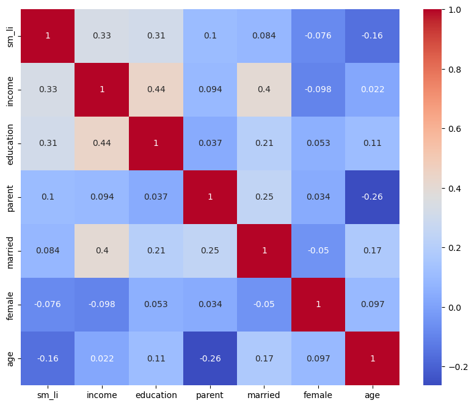

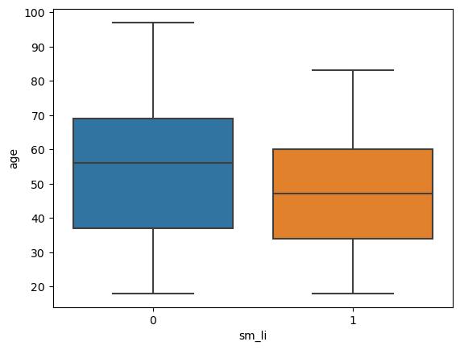

[interactive chart not shown]

```python
# Exploratory Analysis

import seaborn as sns
import matplotlib.pyplot as plt
import altair as alt

# Correlation Matrix
corr = ss.corr()
plt.figure(figsize=(10, 8))
sns.heatmap(corr, annot=True, cmap='coolwarm')
plt.show()

# Boxplot for age vs sm_li
sns.boxplot(x='sm_li', y='age', data=ss)
plt.show()

# sm_li vs age vs education
chart = alt.Chart(ss).mark_circle().encode(
    x='age',
    y='education',
    color=alt.Color('sm_li:N', legend=alt.Legend(title='LinkedIn Usage'))  # Change legend title for 'sm_li'
)

text = alt.Chart({'values':[{}]}).mark_text(
    align='left',
    baseline='top',
    dx=5,
    dy=5,
    text='Note: education = 1 means "less than high school" and 8 means "Postgraduate or professional degree"'
).encode(
    x=alt.value(1),
    y=alt.value(195)
)

annotated_chart = chart + text

annotated_chart.display()
```

#### Q4

```python
# Target (y) and feature(s) selection (X)
y = ss["sm_li"]
X = ss[["income", "education", "parent", "married", "female", "age"]]

X.head(), y.head()
```

```
(  income education  parent  married  female   age
 0      6         4       0        0       1  77.0
 1      5         3       0        0       0  59.0
 2      8         4       0        1       1  60.0
 3      8         8       0        0       0  73.0
 4      7         8       0        1       1  65.0,
 0    0
 1    0
 2    0
 3    0
 4    1
 Name: sm_li, dtype: int64)
```

#### Q5

```python
# Split data into training and test set

from sklearn.model_selection import train_test_split

X_train, X_test, y_train, y_test = train_test_split(X,
                                                    y,
                                                    stratify=y,       # same number of target in training & test set
                                                    test_size=0.2,    # hold out 20% of data for testing
                                                    random_state=123) # set for reproducibility
```

#### Explanation:

#### X_train and y_train comprise 80% of the overall dataset. X_train includes the features that will be used to train the model, while y_train consists of the corresponding target values that the model will learn to predict during training.

#### X_test and y_test together comprise 20% of the original dataset. X_test includes the features that will be used to evaluate the model's performance on data it has not been trained on. y_test holds the corresponding target values that the model has been trained to predict.

```python
print(f"Training set dimensions are X = {X_train.shape} and y = {y_train.shape}")
print(f"Test set dimensions are X = {X_test.shape} and y = {y_test.shape}")
```

```
Training set dimensions are X = (1008, 6) and y = (1008,)
Test set dimensions are X = (252, 6) and y = (252,)
```

#### Q6

```python
from sklearn.linear_model import LogisticRegression

log_reg = LogisticRegression(class_weight='balanced')

log_reg.fit(X_train, y_train)
```

```
LogisticRegression(class_weight='balanced')
```

#### Q7 and Q8

```python
from sklearn.metrics import accuracy_score, confusion_matrix

# Predictions using testing data
y_pred = log_reg.predict(X_test)

# Accuracy
accuracy = accuracy_score(y_test, y_pred)
print("The model accuracy is:", accuracy)
#confusion_matrix(y_test, y_pred)

pd.DataFrame(confusion_matrix(y_test, y_pred),
            columns=["Predicted  as Not Linkedin Users", "Predicted as Linkedin Users"],
            index=["Not Linkedin Users","Linkedin Users"]).style.background_gradient(cmap="PiYG")
```

```
The model accuracy is: 0.7103174603174603
```

|  | Predicted as Not Linkedin Users | Predicted as Linkedin Users |
| --- | --- | --- |
| Not Linkedin Users | 111 | 57 |
| Linkedin Users | 16 | 68 |

#### Interpreting the Confusion Matrix

#### The confusion matrix provides a comprehensive evaluation of the model's ability to distinguish between LinkedIn users and non-users. It correctly identified 111 non-users, suggesting a good specificity, which is crucial for accurately targeting users in marketing initiatives. However, there were 57 instances where the model incorrectly classified non-users as LinkedIn users. This number of false positives may lead to inefficiencies in a marketing strategy by misallocating resources towards those not actually on the platform. Conversely, the model successfully pinpointed 68 actual LinkedIn users, demonstrating a solid sensitivity rate. Yet, the model missed 16 LinkedIn users, classifying them as non-users, which could result in missed opportunities to engage with potential consumers. The balance between sensitivity and specificity, indicates while the model is reasonably good at identifying LinkedIn users, there is room for improvement, especially in reducing the number of non-users it mistakenly classifies as users.

#### Q9

#### Precision = TP / (TP + FP)

#### This metric is important when the cost of a false positive is high. For example, in email spam detection, a high precision means that almost all emails marked as spam are actually spam, minimizing the risk of important emails being incorrectly filtered out.

```python
Precision = 68 / (68 + 57)
print("The Model Precision is", Precision,"meaning that the model is correct about 54.4% of the time when predicting a user is on LinkedIn.")
```

```
The Model Precision is 0.544 meaning that the model is correct about 54.4% of the time when predicting a user is on LinkedIn.
```

#### This metric is crucial when the cost of a false negative is high. For instance, in medical diagnostics for a serious disease, a high recall means that most actual cases of the disease are predicted by the model, minimizing the risk of missing a diagnosis.

```python
Recall = 68 / (68 + 16)
print("The Model Recall is", Recall, "indicating that the model identifies about 81.0% of all LinkedIn users correctly.")
```

```
The Model Recall is 0.8095238095238095 indicating that the model identifies about 81.0% of all LinkedIn users correctly.
```

#### F1 Score = 2 *(Precision* Recall) / (Precision + Recall)

#### This metric is useful when you need a balance between precision and recall. For example, in a search engine, F1 score helps ensure that the returned results are both relevant (precision) and that most of the relevant results are indeed returned (recall).

```python
F1_Score = 2 * (Precision * Recall) / (Precision + Recall)
print("The Model F1 Score is", F1_Score,"indicating moderate accuracy of the model.")
```

```
The Model F1 Score is 0.6507177033492824 indicating moderate accuracy of the model.
```

```python
from sklearn.metrics import classification_report

# Generate classification report using sklearn
print(classification_report(y_test, y_pred))
```

```
              precision    recall  f1-score   support

           0       0.87      0.66      0.75       168
           1       0.54      0.81      0.65        84

    accuracy                           0.71       252
   macro avg       0.71      0.74      0.70       252
weighted avg       0.76      0.71      0.72       252
```

#### Manual calculations matched the classification report for all three metrics

#### Q10

#### Index 0. High income, high level of education, non-parent, married, female and 42 years old.

#### Index 1. High income, high level of education, non-parent, married, female and 82 years old.

```python
newdata = pd.DataFrame({
    'income': [8,8],
    'education': [7,7],
    'parent': [0,0],
    'married': [1,1],
    'female': [1,1],
    'age': [42,82]
})

print(newdata)
```

```
   income  education  parent  married  female  age
0       8          7       0        1       1   42
1       8          7       0        1       1   82
```

```python
newdata["LinkedIn User?"] = log_reg.predict(newdata)
print(newdata)
```

```
   income  education  parent  married  female  age  LinkedIn User?
0       8          7       0        1       1   42               1
1       8          7       0        1       1   82               0
```

### Streamlit

```python
import streamlit as st

st.markdown("<h3 style='color: red;'>Are you on LinkedIn?</h3>", unsafe_allow_html=True)
st.markdown("##### Welcome to our predictive analysis app!")
st.markdown("My goal is to determine the likelihood that someone is a LinkedIn user based on various demographic factors.")
st.markdown("Please take a moment to fill out the following questions. Once you submit your responses, the app will provide you with a prediction of whether you are likely to be a LinkedIn user.")
st.markdown("<h6 style='color: red;'> Let's get started!</h6>", unsafe_allow_html=True)
```

```
DeltaGenerator()
```

#### Income

```python
income_household = {
    "Less than $10k": 1,
    "$10k to under $20k": 2,
    "$20k to under $30k": 3,
    "$30k to under $40k": 4,
    "$40k to under $50k": 5,
    "$50k to under $75k": 6,
    "$75k to under $100k": 7,
    "$100k to under $150k": 8,
    "$150k or more": 9
}

income_key =st.selectbox("What is your annual household income?",list(income_household.keys()))
income_value = income_household[income_key]
```

#### Education Level

```python
education_level = {
    "Less than high school (Grades 1-8 or no formal schooling)": 1,
    "High school incomplete (Grades 9-11 or Grade 12 with NO diploma)": 2,
    "High school graduate (Grade 12 with diploma or GED certificate)": 3,
    "Some college, no degree (includes some community college)": 4,
    "Two-year associate degree from a college or university": 5,
    "Four-year college or university degree/Bachelor’s degree (e.g., BS, BA, AB)": 6,
    "Some postgraduate or professional schooling, no postgraduate degree (e.g. some graduate school)": 7,
    "Postgraduate or professional degree, including master’s, doctorate, medical or law degree (e.g., MA, MS, PhD, MD, JD)": 8
}

education_key = st.selectbox("What is the highest level of education you have completed?", list(education_level.keys()))
education_value = education_level[education_key]
```

#### Parent

```python
parent_options = {
    "Yes": 1,
    "No": 0
}

parent_key = st.radio("Are you the parent of a child under 18 living in your home?", list(parent_options.keys()))

parent_value = parent_options[parent_key]
```

#### Marital Status

```python
marital_status_options = {
    "Married": 1,
    "Not Married": 0
}

marital_key = st.radio("Are you currently married?", list(marital_status_options.keys()))
marital_value = marital_status_options[marital_key]
```

#### Gender

```python
gender_options = {
    "Male": 0,
    "Female": 1
}

gender_key = st.radio("What is your gender?", list(gender_options.keys()))
gender_value = gender_options[gender_key]
```

#### Age

```python
age_value = st.number_input("How old are you?", min_value = 0, max_value = 98, step = 1)
```

#### Input by user

```python
input_by_user = pd.DataFrame({
    "income": [income_value],
    "education": [education_value],
    "parent": [parent_value],
    "married": [marital_value],
    "female": [gender_value],
    "age": [age_value]
})
```

#### Predictions

```python
user_result = None
user_probability = None

if st.button('Predict'):
    user_result = log_reg.predict(input_by_user)[0]
    user_probability = log_reg.predict_proba(input_by_user)[0][1]
```

#### Display Results

```python
if user_result is not None:
    if user_result == 1:
        st.markdown("<h3 style='color: red;'>Yes, you are probably a LinkedIn user!</h3>", unsafe_allow_html=True)
    else:
        st.markdown("<h3 style='color: red;'>No, you are probably not a LinkedIn user.</h3>", unsafe_allow_html=True)
```

```python
st.markdown(f"#### Your probability of using LinkedIn: {user_probability}")
```

```
DeltaGenerator()
```